# Trabalho 2 de ARQ - G13

# Atividade 02 - melhorar o desempenho de RP em conjunto de dados existentes

A atividade 02 visa trabalhar com um conjunto de dados pré-construído, onde as opções que o desenvolvedor tem, são de aplicar as técnicas de pré-processamento abaixo relacionadas:

- Seleção
- Limpeza
- Codificação
- Enriquecimento
- Normalização
- Construção de Atributos
- Correção de Prevalência
- Partição do Conjunto de Dados

Busque uma base de dados na UCI Machine Learning que seja indicada para problemas de classificação. (https://archive.ics.uci.edu/datasets)

Nossa opção foi pela base "Adult Census Income", cujo objetivo é predizer se o valor de income é maior que 50k

O Dataset "Adult" da UCI, também conhecido como "Census Income Dataset", é largamente utilizado para tarefas de classificação para predizer se a soma de valores recebidos anualmente superam $50,000.00 baseado nos atributos demográficos e de emprego. Ele possui 14 atributos (features), tanto categóricas como numéricas, e requer pré-processamento e seleção de atributos para otimizar o desempenho do modelo.

O Dataset possui os seguinte atributos:

- Numéricos: age, fnlwgt, education-num, capital-gain, capital-loss e hours-per-week
- Categóricos: workclass, education, marital-status, occupation, relationship, race, sex e native-country

A variável target é income, que pode assumir dois valores: '<=50K' ou '>50K'.

## 1. Parâmetros globais e carregamento das bibliotecas

```python
# Hyperparametros
RAND_STATE = 13 # em homenagem ao Grupo!!
TEST_SIZE = 0.2 # 20% do Dataset para teste
FIG_SIZE = (8,5) # Tamanho das figuras
```

```python
#  Bibliotecas básicas
import numpy as np
import pandas as pd
from pandas.api.types import is_numeric_dtype
import matplotlib.pyplot as plt
import seaborn as sns

# Bibliotecas para o modelo e avaliação
from sklearn.model_selection import train_test_split
from sklearn.preprocessing import OneHotEncoder
from sklearn.preprocessing import StandardScaler
from sklearn.compose import ColumnTransformer
from sklearn.pipeline import Pipeline
from sklearn.metrics import classification_report, confusion_matrix
from sklearn import svm

# Configuração de exibição
sns.set_style("darkgrid")
```

## 2. Carregamento do Dataset

```python
# Se for rodar esse notebook no Google colab precisa instalar
# a biblioteca ucimlrepo ou copiar o arquivo adult.zip para a pasta
# de arquivos do google colab

try:
   from ucimlrepo import fetch_ucirepo

except ImportError:
    %pip install ucimlrepo #install a biblioteca no google colab
    from ucimlrepo import fetch_ucirepo

# fetch dataset
try:
    # tenda baixar da rede
    adult = fetch_ucirepo(id=2)

    # dados como um Dataframe Pandas
    df = pd.concat([adult.data.features, adult.data.targets], axis=1, ignore_index=False)

    # remove ponto final da coluna income ##bug##
    df["income"] = df["income"].str.replace('.', '', regex=False)

    # Converte '?' em NaN
    df = df.replace("?", np.nan)

    # informação sobre as variáveis
    print("Usando cópia on-line")
    display(adult.variables)

except ConnectionError:
    # usa copia local
    import zipfile
    print("Usando copia local")

    colunas = [
    "age", "workclass", "fnlwgt", "education", "education-num",
    "marital-status", "occupation", "relationship", "race", "sex",
    "capital-gain", "capital-loss", "hours-per-week",
    "native-country", "income"
    ]

    with zipfile.ZipFile("adult.zip") as z:
        with z.open("adult.data") as f:
            train = pd.read_csv(
            f,
            header=None,
            names=colunas,
            na_values="?",
            skipinitialspace=True
            )
        with z.open("adult.test") as f:
            test = pd.read_csv(
            f,
            header=None,
            names=colunas,
            na_values="?",
            skipinitialspace=True
            )
    df = pd.concat([train, test], axis=0, ignore_index=False)
# end of Except

# remove ponto final da coluna income ##bug##
df["income"] = df["income"].str.replace('.', '', regex=False)

# garantir que a coluna 'age' seja tratada como número (bug quando usa a cópia local)
df["age"] = pd.to_numeric(df["age"], errors="coerce").astype("Int64")
```

```
Usando cópia on-line
```

|  | name | role | type | demographic | description | units | missing_values |
| --- | --- | --- | --- | --- | --- | --- | --- |
| 0 | age | Feature | Integer | Age | N/A | None | no |
| 1 | workclass | Feature | Categorical | Income | Private, Self-emp-not-inc, Self-emp-inc, Feder... | None | yes |
| 2 | fnlwgt | Feature | Integer | NaN | NaN | None | no |
| 3 | education | Feature | Categorical | Education Level | Bachelors, Some-college, 11th, HS-grad, Prof-... | None | no |
| 4 | education-num | Feature | Integer | Education Level | NaN | None | no |
| 5 | marital-status | Feature | Categorical | Other | Married-civ-spouse, Divorced, Never-married, S... | None | no |
| 6 | occupation | Feature | Categorical | Other | Tech-support, Craft-repair, Other-service, Sal... | None | yes |
| 7 | relationship | Feature | Categorical | Other | Wife, Own-child, Husband, Not-in-family, Other... | None | no |
| 8 | race | Feature | Categorical | Race | White, Asian-Pac-Islander, Amer-Indian-Eskimo,... | None | no |
| 9 | sex | Feature | Binary | Sex | Female, Male. | None | no |
| 10 | capital-gain | Feature | Integer | NaN | NaN | None | no |
| 11 | capital-loss | Feature | Integer | NaN | NaN | None | no |
| 12 | hours-per-week | Feature | Integer | NaN | NaN | None | no |
| 13 | native-country | Feature | Categorical | Other | United-States, Cambodia, England, Puerto-Rico,... | None | yes |
| 14 | income | Target | Binary | Income | >50K, <=50K. | None | no |

## 3. Resumo dos dados

```python
print("Shape:", df.shape)
df.info()
df.describe().style.background_gradient(cmap='Reds')
```

```
Shape: (48842, 15)
<class 'pandas.DataFrame'>
RangeIndex: 48842 entries, 0 to 48841
Data columns (total 15 columns):
 #   Column          Non-Null Count  Dtype
---  ------          --------------  -----
 0   age             48842 non-null  Int64
 1   workclass       46043 non-null  str
 2   fnlwgt          48842 non-null  int64
 3   education       48842 non-null  str
 4   education-num   48842 non-null  int64
 5   marital-status  48842 non-null  str
 6   occupation      46033 non-null  str
 7   relationship    48842 non-null  str
 8   race            48842 non-null  str
 9   sex             48842 non-null  str
 10  capital-gain    48842 non-null  int64
 11  capital-loss    48842 non-null  int64
 12  hours-per-week  48842 non-null  int64
 13  native-country  47985 non-null  str
 14  income          48842 non-null  str
dtypes: Int64(1), int64(5), str(9)
memory usage: 5.6 MB
```

|  | age | fnlwgt | education-num | capital-gain | capital-loss | hours-per-week |
| --- | --- | --- | --- | --- | --- | --- |
| count | 48842.000000 | 48842.000000 | 48842.000000 | 48842.000000 | 48842.000000 | 48842.000000 |
| mean | 38.643585 | 189664.134597 | 10.078089 | 1079.067626 | 87.502314 | 40.422382 |
| std | 13.710510 | 105604.025423 | 2.570973 | 7452.019058 | 403.004552 | 12.391444 |
| min | 17.000000 | 12285.000000 | 1.000000 | 0.000000 | 0.000000 | 1.000000 |
| 25% | 28.000000 | 117550.500000 | 9.000000 | 0.000000 | 0.000000 | 40.000000 |
| 50% | 37.000000 | 178144.500000 | 10.000000 | 0.000000 | 0.000000 | 40.000000 |
| 75% | 48.000000 | 237642.000000 | 12.000000 | 0.000000 | 0.000000 | 45.000000 |
| max | 90.000000 | 1490400.000000 | 16.000000 | 99999.000000 | 4356.000000 | 99.000000 |

## 4. Limpeza dos dados

```python
print(f'\nDimensões do Dataset: {df.shape[0]} linhas x {df.shape[1]} colunas\n')
```

```
Dimensões do Dataset: 48842 linhas x 15 colunas
```

```python
print("=== Valores faltantes por coluna ===")
missing = df.isnull().sum()
missing_pct = (missing / len(df) * 100).round(2)
missing_df = pd.DataFrame({'Valores Faltantes': missing, 'Percentual (%)': missing_pct})
print(missing_df[missing_df['Valores Faltantes'] > 0])
```

```
=== Valores faltantes por coluna ===
                Valores Faltantes  Percentual (%)
workclass                    2799            5.73
occupation                   2809            5.75
native-country                857            1.75
```

```python
# Substitui valores faltantes pela moda ou média
for col in df.columns:
    if is_numeric_dtype(df[col]):
        df[col] = df[col].fillna(df[col].median())
    else:
        df[col] = df[col].fillna(df[col].mode()[0])
```

```python
# Verifica se existe linhas duplicadas
print(f'=== Verificação de Dados Duplicados ===')

duplicadas = df.duplicated().sum()
print(f'Total de linhas duplicadas: {duplicadas:,}')

# remoção de linhas duplicadas
if duplicadas > 0:
  print("\nIndice das linhas duplicadas:")
  print(df[df.duplicated(keep=False)].index.values)
  df = df.drop_duplicates()
  print(f'\nLinhas após remoção de duplicatas: {len(df):}')
else:
  print('\nNenhuma linha duplicata encontrada. Nenhuma ação necessária.')
```

```
=== Verificação de Dados Duplicados ===
Total de linhas duplicadas: 53

Indice das linhas duplicadas:
[ 2195  2303  3118  3445  3917  4325  4767  4881  4940  5104  5579  5805
  5842  6990  7053  7920  8080  8679  8908  9171  9371  9841 10094 10367
 11631 11965 13084 14581 14690 15059 15189 16297 16846 16975 17040 17673
 17867 17916 18555 18698 19567 20486 20567 20883 21103 21318 21490 21875
 21974 22249 22300 22367 22494 24667 25624 25684 25872 26313 27920 28230
 28522 28846 29157 30345 30384 30698 30845 31993 32404 33049 33425 33880
 34229 34415 34424 36461 36713 37419 37639 38343 38468 38993 39017 39582
 39911 40677 41810 42386 43387 43484 43750 43773 44307 45049 46065 46409
 46714 46869 46959 47048 47399 47884 48521]

Linhas após remoção de duplicatas: 48789
```

## 5. Análise exploratória de dados

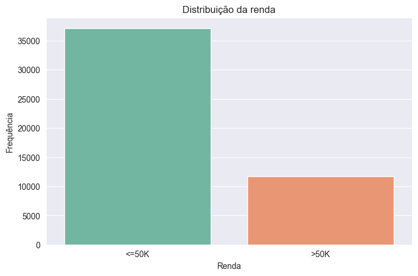

```python
plt.figure(figsize=FIG_SIZE)
sns.countplot(data=df, x="income", hue="income", palette="Set2")
plt.title("Distribuição da renda")
plt.xlabel("Renda")
plt.ylabel("Frequência")
plt.show()
```

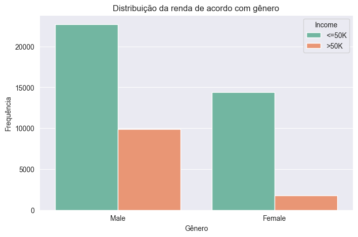

```python
plt.figure(figsize=FIG_SIZE)
sns.countplot(data=df, x="sex", hue="income", palette="Set2")
plt.title("Distribuição da renda de acordo com gênero")
plt.xlabel("Gênero")
plt.ylabel("Frequência")
plt.legend(title="Income")
plt.show()
```

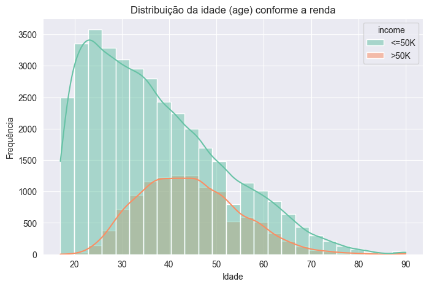

```python
plt.figure(figsize=FIG_SIZE)
sns.histplot(data=df, x="age", hue="income", bins=25, palette="Set2", kde=True)
plt.title("Distribuição da idade (age) conforme a renda")
plt.xlabel("Idade")
plt.ylabel("Frequência")
plt.show()
```

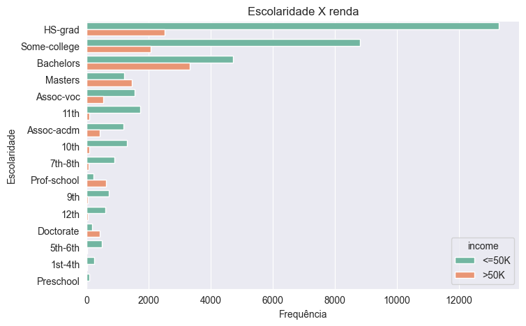

```python
plt.figure(figsize=FIG_SIZE)
order = df["education"].value_counts().index
sns.countplot(data=df, y="education", order=order, hue="income", palette="Set2")
plt.title("Escolaridade X renda")
plt.xlabel("Frequência")
plt.ylabel("Escolaridade")
plt.show()
```

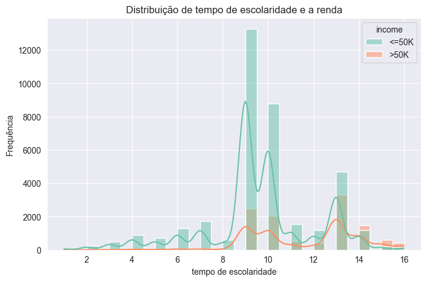

```python
plt.figure(figsize=FIG_SIZE)
sns.histplot(
    data=df,
    x="education-num",
    hue="income",
    bins=30,
    kde=True,
    palette="Set2"
)

plt.title("Distribuição de tempo de escolaridade e a renda")
plt.xlabel("tempo de escolaridade")
plt.ylabel("Frequência")
plt.show()
```

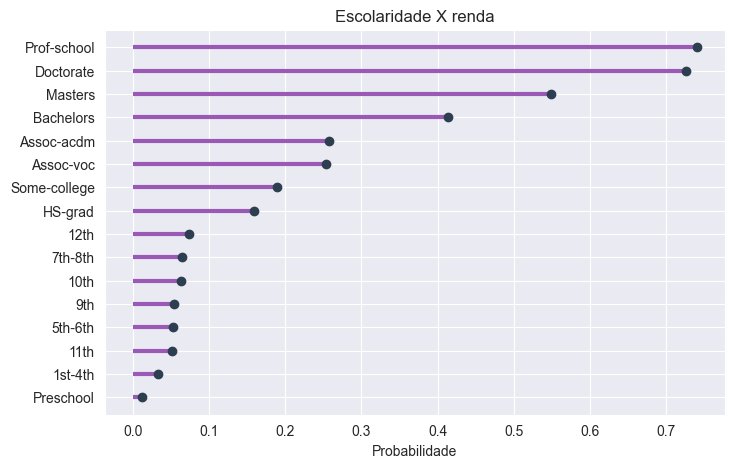

```python
edu_income = (
    df.groupby("education")["income"]
    .apply(lambda x: (x == ">50K").mean())
    .sort_values()
)

plt.figure(figsize=FIG_SIZE)
plt.hlines(
    y=edu_income.index,
    xmin=0,
    xmax=edu_income.values,
    color="#9b59b6",
    linewidth=3
)
plt.plot(
    edu_income.values,
    edu_income.index,
    "o",
    color="#2c3e50"
)

plt.title("Escolaridade X renda")
plt.xlabel("Probabilidade")
plt.show()
```

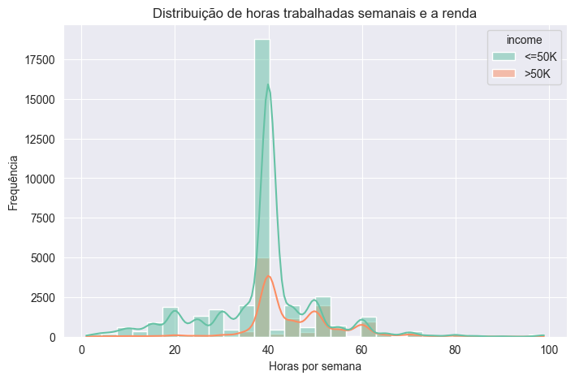

```python
plt.figure(figsize=FIG_SIZE)
sns.histplot(
    data=df,
    x="hours-per-week",
    hue="income",
    bins=30,
    kde=True,
    palette="Set2"
)

plt.title("Distribuição de horas trabalhadas semanais e a renda")
plt.xlabel("Horas por semana")
plt.ylabel("Frequência")
plt.show()
```

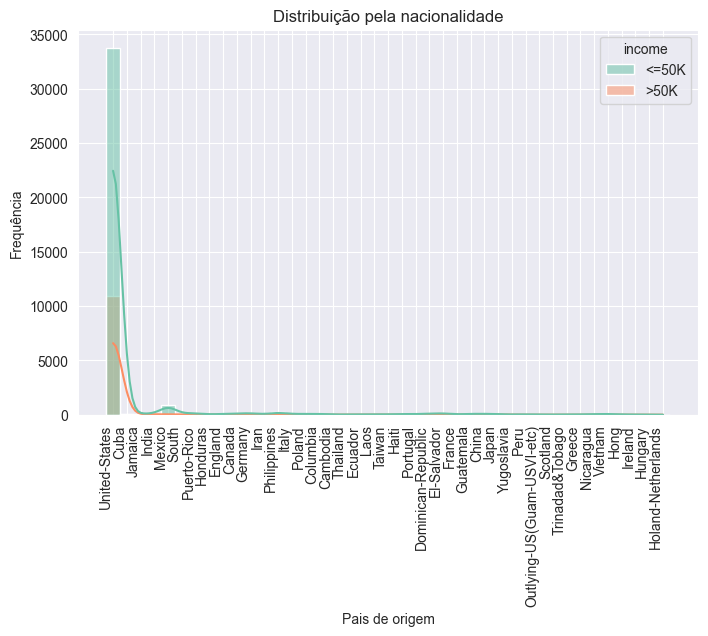

```python
plt.figure(figsize=FIG_SIZE)
sns.histplot(
    data=df,
    x="native-country",
    hue="income",
    bins=30,
    kde=True,
    palette="Set2"
)

plt.title("Distribuição pela nacionalidade")
plt.xticks(rotation=90, ha='right')
plt.xlabel("Pais de origem")
plt.ylabel("Frequência")
plt.show()
```

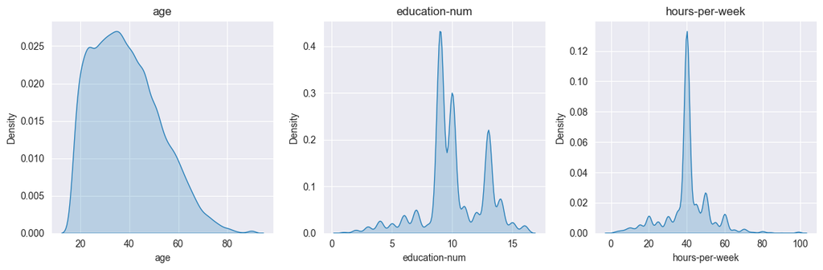

```python
# Verifica a distribuição de algumas features numéricas
num_features = ["age", "education-num", "hours-per-week"]

plt.figure(figsize=(12,4))
for i, col in enumerate(num_features, 1):
    plt.subplot(1,3,i)
    sns.kdeplot(df[col], fill=True, color="#2980b9")
    plt.title(col)

plt.tight_layout()
plt.show()
```

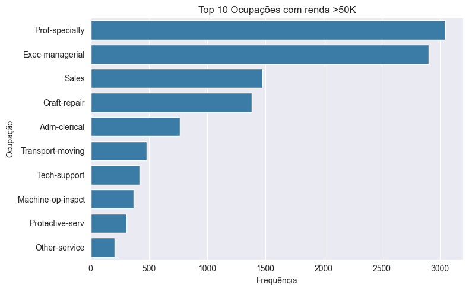

```python
# Filtrar income >50K
df_high_income = df[df['income'] == '>50K']

# Contar occupations
top_occupations = (
    df_high_income['occupation']
    .value_counts()
    .head(10)
)

# Plot
plt.figure(figsize=FIG_SIZE)

sns.barplot(
    x=top_occupations.values,
    y=top_occupations.index,
    color="#2980b9"
)

plt.title("Top 10 Ocupações com renda >50K")
plt.xlabel("Frequência")
plt.ylabel("Ocupação")

plt.tight_layout()
plt.show()
```

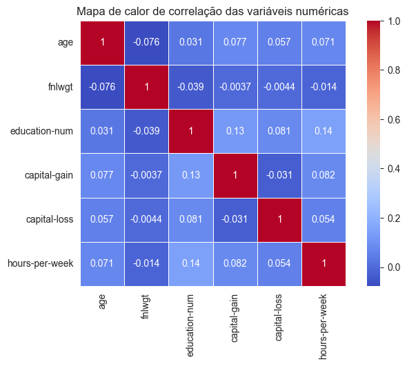

```python
num_cols = df.select_dtypes(include="number").columns.tolist()

corr = df[num_cols].corr()

plt.figure(figsize=FIG_SIZE)
sns.heatmap(
    corr,
    annot=True,
    cmap="coolwarm",
    linewidths=0.5,
    square=True
)

plt.title("Mapa de calor de correlação das variáveis numéricas")
plt.show()
```

## 6. Redução de dimensionalidade

```python
# vamos remover 'fnlwgt' e 'capital-loss' do dataset
df = df.drop(['fnlwgt', 'capital-loss'], axis=1)
```

```python
# A coluna 'education' pode ser removida em favor da coluna 'education_num' que representa o número de anos de educação
df = df.drop(['education'], axis=1)
```

## 7. Análise das variáveis categóricas

```python
# Verifica a quantidades de classes das variáveis categóricas
df.select_dtypes(include=["string","object"]).nunique().sort_values(ascending=False)
```

```
native-country    41
occupation        14
workclass          8
marital-status     7
relationship       6
race               5
sex                2
income             2
dtype: int64
```

```python
# Verifica a cardinalidade de 'native-country' pois é a variável com maior número de classes
freq = df['native-country'].value_counts()
print(freq)
```

```
native-country
United-States                 44647
Mexico                          943
Philippines                     294
Germany                         206
Puerto-Rico                     184
Canada                          182
El-Salvador                     155
India                           151
Cuba                            138
England                         127
China                           122
South                           115
Jamaica                         106
Italy                           105
Dominican-Republic              103
Japan                            92
Poland                           87
Guatemala                        86
Vietnam                          86
Columbia                         85
Haiti                            75
Portugal                         67
Taiwan                           65
Iran                             59
Greece                           49
Nicaragua                        49
Peru                             46
Ecuador                          45
France                           38
Ireland                          37
Thailand                         30
Hong                             30
Cambodia                         28
Trinadad&Tobago                  27
Laos                             23
Yugoslavia                       23
Outlying-US(Guam-USVI-etc)       23
Scotland                         21
Honduras                         20
Hungary                          19
Holand-Netherlands                1
Name: count, dtype: int64
```

```python
# Com a predominância de uma classe, vamos converter em apenas duas classes

# obter a classe dominante
dominante = df['native-country'].value_counts().idxmax()

# converte para binário
df['native-country'] = (df['native-country'] == dominante).astype(int)
```

```python
# Vamos verificar a distribuição de classes em 'occupation'
freq = df['occupation'].value_counts()
print(freq)
```

```
occupation
Prof-specialty       8969
Craft-repair         6102
Exec-managerial      6082
Adm-clerical         5606
Sales                5501
Other-service        4919
Machine-op-inspct    3017
Transport-moving     2355
Handlers-cleaners    2071
Farming-fishing      1485
Tech-support         1445
Protective-serv       982
Priv-house-serv       240
Armed-Forces           15
Name: count, dtype: int64
```

```python
# Vamos tratar como Other-service, todas as classes abaixo de 5000
rare = freq[freq < 5000].index

df["occupation"] = (
    df["occupation"]
    .replace(rare, "Other-service")
)
```

```python
# Verifica a quantidades de classes das colunas descritivas remanescentes
df.select_dtypes(include=["string", "object"]).nunique().sort_values(ascending=False)
```

```
workclass         8
marital-status    7
occupation        6
relationship      6
race              5
sex               2
income            2
dtype: int64
```

```python
# Converte a coluna target onde os valores só possuem duas classes

df['income'] = df['income'].map({
    "<=50K": 0,
    ">50K": 1
}).astype(int)
```

## 8. Separação de Features e Target

```python
# Separar features & target
X = df.drop("income", axis=1)

# Converte target em binário
y = df["income"]

# Identifica features numéricas e categóricas
num_cols = X.select_dtypes(include=["number"]).columns
cat_cols = X.select_dtypes(include=["string", "object"]).columns
```

## 9. Divisão em Treino e Teste

```python
# Train/test split - mantem a mesma proporção do target no treino e teste
X_train, X_test, y_train, y_test = train_test_split(X, y, test_size=TEST_SIZE, random_state=RAND_STATE, stratify=y)
```

## 10. Modelo (SVM) - sem padronização

```python
# Algoritmo escolhido foi o SVM

cat_transform = OneHotEncoder(handle_unknown="ignore")
preprocess = ColumnTransformer([
    ("categorical", cat_transform, cat_cols)],
    remainder="passthrough"
)

# Modelo sem padronização do dados
model = Pipeline([
    ("preprocess", preprocess),
    ("model", svm.SVC())
])

model.fit(X_train, y_train)
```

```
Pipeline(steps=[('preprocess',
                 ColumnTransformer(remainder='passthrough',
                                   transformers=[('categorical',
                                                  OneHotEncoder(handle_unknown='ignore'),
                                                  Index(['workclass', 'marital-status', 'occupation', 'relationship', 'race',
       'sex'],
      dtype='str'))])),
                ('model', SVC())])
```

```python
# predição com os mesmos dados usados para treinar
y_pred_train = model.predict(X_train)

print('Matriz de confusão - com os dados ORIGINAIS usados no TREINAMENTO')
cm_orig_train = confusion_matrix(y_train, y_pred_train)
print(cm_orig_train)
print(classification_report(y_train, y_pred_train))

# predição com os mesmos dados usados para testar
y_pred_teste = model.predict(X_test)

print('Matriz de confusão - com os dados ORIGINAIS usados para TESTE')
cm_orig_test = confusion_matrix(y_test, y_pred_teste)
print(cm_orig_test)
print(classification_report(y_test, y_pred_teste))
```

```
Matriz de confusão - com os dados ORIGINAIS usados no TREINAMENTO
[[29616    70]
 [ 7709  1636]]
              precision    recall  f1-score   support

           0       0.79      1.00      0.88     29686
           1       0.96      0.18      0.30      9345

    accuracy                           0.80     39031
   macro avg       0.88      0.59      0.59     39031
weighted avg       0.83      0.80      0.74     39031

Matriz de confusão - com os dados ORIGINAIS usados para TESTE
[[7402   20]
 [1916  420]]
              precision    recall  f1-score   support

           0       0.79      1.00      0.88      7422
           1       0.95      0.18      0.30      2336

    accuracy                           0.80      9758
   macro avg       0.87      0.59      0.59      9758
weighted avg       0.83      0.80      0.75      9758
```

## 11. Modelo SVM Aplicando padronização dos dados

```python
# =========================================================
# Pipeline numérico
# =========================================================

numeric_transformer = Pipeline(steps=[
    ("scaler", StandardScaler())
])

# =========================================================
# Pipeline categórico
# =========================================================

categorical_transformer = Pipeline(steps=[
    ("onehot", OneHotEncoder(handle_unknown="ignore"))
])

# =========================================================
# Pré-processamento completo
# =========================================================

preprocessor = ColumnTransformer(
    transformers=[
        ("num", numeric_transformer, num_cols),
        ("cat", categorical_transformer, cat_cols)
    ]
)

# =========================================================
# Pipeline final com SVM
# =========================================================

model = Pipeline(steps=[
    ("preprocessor", preprocessor),
    ("classifier", svm.SVC(
        kernel="rbf",
        C=1.0,
        gamma="scale"
    ))
])

model.fit(X_train, y_train)
```

```
Pipeline(steps=[('preprocessor',
                 ColumnTransformer(transformers=[('num',
                                                  Pipeline(steps=[('scaler',
                                                                   StandardScaler())]),
                                                  Index(['age', 'education-num', 'capital-gain', 'hours-per-week',
       'native-country'],
      dtype='str')),
                                                 ('cat',
                                                  Pipeline(steps=[('onehot',
                                                                   OneHotEncoder(handle_unknown='ignore'))]),
                                                  Index(['workclass', 'marital-status', 'occupation', 'relationship', 'race',
       'sex'],
      dtype='str'))])),
                ('classifier', SVC())])
```

```python
# predição com os mesmos dados usados para treinar
y_pred_train = model.predict(X_train)

print('Matriz de confusão - com os dados PADRONIZADOS usados no TREINAMENTO')
cm_orig_train = confusion_matrix(y_train, y_pred_train)
print(cm_orig_train)
print(classification_report(y_train, y_pred_train))

# predição com os mesmos dados usados para testar
y_pred_teste = model.predict(X_test)

print('Matriz de confusão - com os dados PADRONIZADOS usados para TESTE')
cm_orig_test = confusion_matrix(y_test, y_pred_teste)
print(cm_orig_test)
print(classification_report(y_test, y_pred_teste))
```

```
Matriz de confusão - com os dados PADRONIZADOS usados no TREINAMENTO
[[28166  1520]
 [ 4144  5201]]
              precision    recall  f1-score   support

           0       0.87      0.95      0.91     29686
           1       0.77      0.56      0.65      9345

    accuracy                           0.85     39031
   macro avg       0.82      0.75      0.78     39031
weighted avg       0.85      0.85      0.85     39031

Matriz de confusão - com os dados PADRONIZADOS usados para TESTE
[[7037  385]
 [1066 1270]]
              precision    recall  f1-score   support

           0       0.87      0.95      0.91      7422
           1       0.77      0.54      0.64      2336

    accuracy                           0.85      9758
   macro avg       0.82      0.75      0.77      9758
weighted avg       0.84      0.85      0.84      9758
```

## 12. Usando modelo Xgboost para classificar

```python
from xgboost import XGBClassifier
from sklearn.preprocessing import OrdinalEncoder

# =========================================================
# Pipeline numérico
# =========================================================

numeric_transformer = Pipeline(steps=[
    ("scaler", StandardScaler())
])

# =========================================================
# Pipeline categórico
# =========================================================

categorical_transformer = Pipeline(steps=[
    ("labelencoder", OrdinalEncoder())
])

# =========================================================
# Pré-processamento completo
# =========================================================

preprocessor = ColumnTransformer(
    transformers=[
        ("num", numeric_transformer, num_cols),
        ("cat", categorical_transformer, cat_cols)
    ]
)

# =========================================================
# Pipeline final com Xgboost
# =========================================================

model = Pipeline(steps=[
    ("preprocessor", preprocessor),
    ("classifier", XGBClassifier(
            n_estimators=200,
            max_depth=6,
            learning_rate=0.1,
            subsample=0.8,
            colsample_bytree=0.8,
            objective="binary:logistic",
            eval_metric="logloss",
            random_state=RAND_STATE
    ))
])

model.fit(X_train, y_train)
```

```
Pipeline(steps=[('preprocessor',
                 ColumnTransformer(transformers=[('num',
                                                  Pipeline(steps=[('scaler',
                                                                   StandardScaler())]),
                                                  Index(['age', 'education-num', 'capital-gain', 'hours-per-week',
       'native-country'],
      dtype='str')),
                                                 ('cat',
                                                  Pipeline(steps=[('labelencoder',
                                                                   OrdinalEncoder())]),
                                                  Index(['workclass', 'marital-status', 'occupation', 'relationship', 'race',
       'sex'],
      dty...
                               feature_types=None, feature_weights=None,
                               gamma=None, grow_policy=None,
                               importance_type=None,
                               interaction_constraints=None, learning_rate=0.1,
                               max_bin=None, max_cat_threshold=None,
                               max_cat_to_onehot=None, max_delta_step=None,
                               max_depth=6, max_leaves=None,
                               min_child_weight=None, missing=nan,
                               monotone_constraints=None, multi_strategy=None,
                               n_estimators=200, n_jobs=None,
                               num_parallel_tree=None, ...))])
```

```python
# predição com os mesmos dados usados para treinar
y_pred_train = model.predict(X_train)

print('Matriz de confusão - com os dados PADRONIZADOS e modelo XGBoost usados no TREINAMENTO')
cm_orig_train = confusion_matrix(y_train, y_pred_train)
print(cm_orig_train)
print(classification_report(y_train, y_pred_train))

# predição com os mesmos dados usados para testar
y_pred_teste = model.predict(X_test)

print('Matriz de confusão - com os dados PADRONIZADOS e modelo XGBoost usados para TESTE')
cm_orig_test = confusion_matrix(y_test, y_pred_teste)
print(cm_orig_test)
print(classification_report(y_test, y_pred_teste))
```

```
Matriz de confusão - com os dados PADRONIZADOS e modelo XGBoost usados no TREINAMENTO
[[28069  1617]
 [ 3172  6173]]
              precision    recall  f1-score   support

           0       0.90      0.95      0.92     29686
           1       0.79      0.66      0.72      9345

    accuracy                           0.88     39031
   macro avg       0.85      0.80      0.82     39031
weighted avg       0.87      0.88      0.87     39031

Matriz de confusão - com os dados PADRONIZADOS e modelo XGBoost usados para TESTE
[[6969  453]
 [ 891 1445]]
              precision    recall  f1-score   support

           0       0.89      0.94      0.91      7422
           1       0.76      0.62      0.68      2336

    accuracy                           0.86      9758
   macro avg       0.82      0.78      0.80      9758
weighted avg       0.86      0.86      0.86      9758
```